# Industrial Production Mining & Crude oil forecast

## Dataset location :

https://fred.stlouisfed.org/series/IPG211111CN

## Objective :

### Why important:

Time series analysis gives us the future forecast about requirement/demand of object, because of businessesses can determine future action plan accordingly.

### What is objective of model:

Using the model, one can determind the future forecast of production of mining of cruide oil

This is the dataset from Fred Economic research about time series forecasting related to the Industrial Production mining & crude oil. Now day's there is lot of demand for oil and its product & to supply it worldwide we need to find out its usage value so that we can predict the crude oil requirement in future & its production. So considering it, Industries need to forecast there production and capacity that they can supply.

This Dataset is in Monthly frequency format available from 1972 to April 2019.

There are lot of technical & statisticals methods are available to forecast time series Problem, Here , we will Forecast the Crude oil prediction using below 3 technique

1. Using Facebook Prophet
2. Using LSTM with Keras
3. Using ARIMA and other models with statsmodels

So let's get started with Time series analysis.

## Facebook Prophet

```python
# Analysis library
import pandas as pd

#visualization library
import matplotlib.pyplot as plt

# time series library
from fbprophet import Prophet
import warnings
from statsmodels.tools.eval_measures import rmse
from fbprophet.plot import add_changepoints_to_plot
```

```python
warnings.filterwarnings('ignore')
```

### Data Analysis

```python
data=pd.read_csv('IPG211111CN.csv').round(2)
```

```python
data.head()
```

|  | DATE | IPG211111CN |
| --- | --- | --- |
| 0 | 1972-01-01 | 141.51 |
| 1 | 1972-02-01 | 145.17 |
| 2 | 1972-03-01 | 147.29 |
| 3 | 1972-04-01 | 148.22 |
| 4 | 1972-05-01 | 149.78 |

```python
data.columns=['ds','y']
data['ds']=pd.to_datetime(data['ds'])
```

```python
data.info()
```

```
<class 'pandas.core.frame.DataFrame'>
RangeIndex: 568 entries, 0 to 567
Data columns (total 2 columns):
ds    568 non-null datetime64[ns]
y     568 non-null float64
dtypes: datetime64[ns](1), float64(1)
memory usage: 9.0 KB
```

### visualization

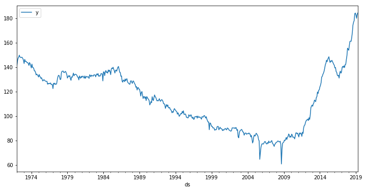

```python
data.plot(figsize=(12,6),x='ds',y='y')
```

### Split the dataset for training & Testing purpose

```python
train=data.iloc[:556]
test=data.iloc[556:]
```

### Model creation

1. As earlier mentioned, we are using fbprophet library for forecasting time series
2. using Phophet(), lets initalize the model
3. then train the model using fit()
4. In prophet we need to use make_future_dataframe() wehere we need to give input for which we need to make forecasting and frequency of the datset
5. here we are providing periods=12 and freq='MS'
6. after predicting the future price, lets look into its results.
7. from forecast , we require only 2 columns 'ds' & 'yhat'

```python
crude=Prophet(interval_width=0.95)
crude.fit(train)
future=crude.make_future_dataframe(12,freq='MS')
forecast=crude.predict(future)
```

```
INFO:fbprophet:Disabling weekly seasonality. Run prophet with weekly_seasonality=True to override this.
INFO:fbprophet:Disabling daily seasonality. Run prophet with daily_seasonality=True to override this.
```

```python
forecast
```

[output not shown]

568 rows × 16 columns

### Root mean square error for model

1. we use statsmodels rmse error to find out error from both the results
2. its look like 15.75 is quite high rmse score , means our model has predicted results but it is quire expensive and not accurate

```python
prediction=forecast[-12:]['yhat']
rmse(prediction,test['y'])
```

```
15.75445809633732
```

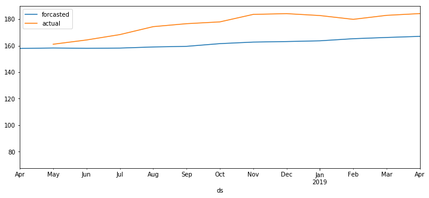

```python
ax=forecast.plot(x='ds',y='yhat',label='forcasted',figsize=(12,5))
test.plot(x='ds',y='y',ax=ax,label='actual',xlim=('2018-04-01','2019-04-01'))
```

```python
crude1=Prophet(seasonality_mode='multiplicative',interval_width=0.95)
crude1.fit(train)
future1=crude1.make_future_dataframe(12,freq='MS')
forecast1=crude1.predict(future1)
```

```
INFO:fbprophet:Disabling weekly seasonality. Run prophet with weekly_seasonality=True to override this.
INFO:fbprophet:Disabling daily seasonality. Run prophet with daily_seasonality=True to override this.
```

```python
prediction1=forecast1[-12:]['yhat']
rmse(prediction1,test['y'])
```

```
15.577087675889885
```

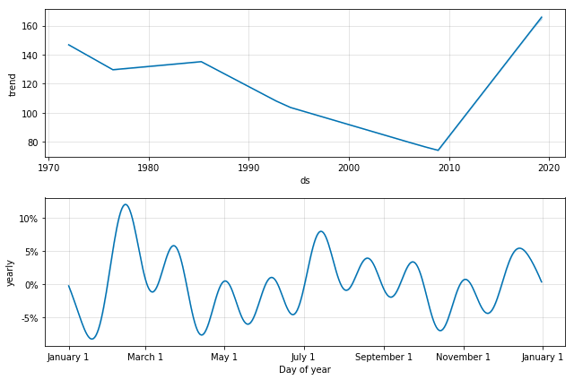

```python
fig=crude1.plot_components(forecast1)
```

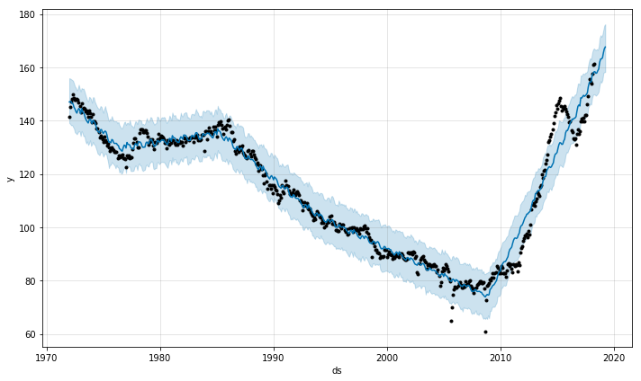

```python
fig=crude1.plot(forecast1)
```

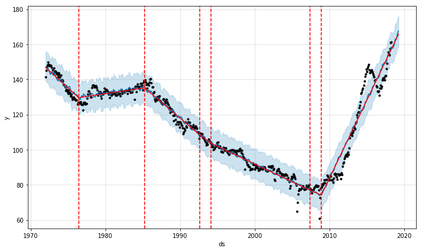

```python
fig=crude1.plot(forecast1)
a=add_changepoints_to_plot(fig.gca(),crude1,forecast1)
```

### Use the model & Predict the future value for next 12 months

```python
crude1=Prophet(seasonality_mode='multiplicative',interval_width=0.95)
crude1.fit(data)
future1=crude1.make_future_dataframe(12,freq='MS')
forecast1=crude1.predict(future1)
```

```
INFO:fbprophet:Disabling weekly seasonality. Run prophet with weekly_seasonality=True to override this.
INFO:fbprophet:Disabling daily seasonality. Run prophet with daily_seasonality=True to override this.
```

```python
forecast1.iloc[568:]
```

|  | ds | trend | yhat_lower | yhat_upper | trend_lower | trend_upper | multiplicative_terms | multiplicative_terms_lower | multiplicative_terms_upper | yearly | yearly_lower | yearly_upper | additive_terms | additive_terms_lower | additive_terms_upper | yhat |
| --- | --- | --- | --- | --- | --- | --- | --- | --- | --- | --- | --- | --- | --- | --- | --- | --- |
| 568 | 2019-05-01 | 172.928182 | 164.152138 | 181.989100 | 172.928182 | 172.933030 | 0.000883 | 0.000883 | 0.000883 | 0.000883 | 0.000883 | 0.000883 | 0.0 | 0.0 | 0.0 | 173.080916 |
| 569 | 2019-06-01 | 173.772180 | 163.646076 | 180.908057 | 173.755397 | 173.823011 | -0.007052 | -0.007052 | -0.007052 | -0.007052 | -0.007052 | -0.007052 | 0.0 | 0.0 | 0.0 | 172.546784 |
| 570 | 2019-07-01 | 174.588952 | 163.737773 | 182.068359 | 174.509541 | 174.724726 | -0.010162 | -0.010162 | -0.010162 | -0.010162 | -0.010162 | -0.010162 | 0.0 | 0.0 | 0.0 | 172.814777 |
| 571 | 2019-08-01 | 175.432949 | 165.557298 | 182.911193 | 175.294081 | 175.680388 | -0.004983 | -0.004983 | -0.004983 | -0.004983 | -0.004983 | -0.004983 | 0.0 | 0.0 | 0.0 | 174.558775 |
| 572 | 2019-09-01 | 176.276947 | 166.665875 | 183.645188 | 176.056213 | 176.617336 | -0.004909 | -0.004909 | -0.004909 | -0.004909 | -0.004909 | -0.004909 | 0.0 | 0.0 | 0.0 | 175.411545 |
| 573 | 2019-10-01 | 177.093719 | 169.470310 | 187.268608 | 176.714635 | 177.547958 | 0.005847 | 0.005847 | 0.005847 | 0.005847 | 0.005847 | 0.005847 | 0.0 | 0.0 | 0.0 | 178.129212 |
| 574 | 2019-11-01 | 177.937716 | 170.843367 | 188.627525 | 177.445249 | 178.531514 | 0.008063 | 0.008063 | 0.008063 | 0.008063 | 0.008063 | 0.008063 | 0.0 | 0.0 | 0.0 | 179.372449 |
| 575 | 2019-12-01 | 178.754488 | 169.928203 | 187.944156 | 178.110720 | 179.476390 | 0.002750 | 0.002750 | 0.002750 | 0.002750 | 0.002750 | 0.002750 | 0.0 | 0.0 | 0.0 | 179.246076 |
| 576 | 2020-01-01 | 179.598486 | 171.343081 | 188.604743 | 178.825402 | 180.514258 | 0.002147 | 0.002147 | 0.002147 | 0.002147 | 0.002147 | 0.002147 | 0.0 | 0.0 | 0.0 | 179.984168 |
| 577 | 2020-02-01 | 180.442483 | 171.736826 | 189.480785 | 179.528677 | 181.462340 | 0.002088 | 0.002088 | 0.002088 | 0.002088 | 0.002088 | 0.002088 | 0.0 | 0.0 | 0.0 | 180.819185 |
| 578 | 2020-03-01 | 181.232029 | 172.675240 | 191.057969 | 180.146410 | 182.436002 | 0.005184 | 0.005184 | 0.005184 | 0.005184 | 0.005184 | 0.005184 | 0.0 | 0.0 | 0.0 | 182.171508 |
| 579 | 2020-04-01 | 182.076027 | 174.037429 | 191.311666 | 180.842048 | 183.475424 | 0.001941 | 0.001941 | 0.001941 | 0.001941 | 0.001941 | 0.001941 | 0.0 | 0.0 | 0.0 | 182.429469 |

### forecasting visualization of next 12 months

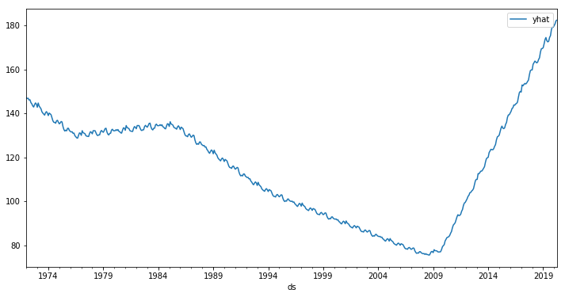

```python
forecast1.plot(x='ds',y='yhat',figsize=(12,6))
```

## LSTM Keras

1. import the keras library
2. from keras we have to import sequencial
3. for prediction , we are using LSTM
4. ans also import Dense & TimeseriesGenerator

```python
## LSTM Keras forecasting
import pandas as pd
import matplotlib.pyplot as plt
import numpy as np

import warnings
from statsmodels.tools.eval_measures import rmse

from sklearn.preprocessing import MinMaxScaler

from keras.preprocessing.sequence import TimeseriesGenerator

from keras.models import Sequential
from keras.layers import LSTM
from keras.layers import Dense
```

```python
data1=pd.read_csv('IPG211111CN.csv',index_col='DATE',parse_dates=True).round(2)
```

```python
data1.head()
```

| DATE | IPG211111CN |
| --- | --- |
| 1972-01-01 | 141.51 |
| 1972-02-01 | 145.17 |
| 1972-03-01 | 147.29 |
| 1972-04-01 | 148.22 |
| 1972-05-01 | 149.78 |

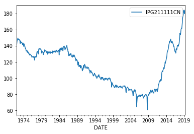

```python
data1.plot()
```

```python
len(data1)
```

```
568
```

```python
train=data1.iloc[:556]
test=data1.iloc[556:]
```

1. Above code for analysis purpose is same as we did earliar with prophet, we just repeat it to avoid confusion.
2. In LSTM, as as target variable has not symmetrical dustrubution so, we are converting it into specific range like 0 - 1.
3. for that we are using sklearn MinMaxScaler functionality which convert ferature into 0-1 range
4. then apply it on train & test dataset

```python
scaler = MinMaxScaler()
scaler.fit(train)
scaled_train = scaler.transform(train)
scaled_test = scaler.transform(test)
```

1. In Timeseriesgenerator, we are going to make batch of input and next one is its results
2. for example, if we set lenght=2 and batchsize=1, and where we want to apply it on then it convert dataset into as first 2 rows is input and third row is output and so on.

```python
#Time series generator
generator=TimeseriesGenerator(scaled_train, scaled_train, length=2, batch_size=1)
```

```python
len(scaled_train)
```

```
556
```

```python
len(generator)
```

```
554
```

```python
generator[0]
```

```
(array([[[0.80337191],
         [0.83988428]]]), array([[0.86103352]]))
```

we are setting TimeseriesGenerator parameter as

length=12,with 1 feauture and batchsize=1

1. now lets initalize th sequential() method
2. and add LSTM with first 100 neurons (this is starting range, later we can increase it with according to results)
3. add activation='tanh', here we add other activation function like sigmoid,relu and many other but I have tried with tanh and give me better results than others

```python
n_inputs=12
n_features=1
generator_train=TimeseriesGenerator(scaled_train, scaled_train, length=n_inputs, batch_size=1)
```

```python
model=Sequential()
model.add(LSTM(100,activation='tanh',input_shape=(n_inputs,n_features)))
model.add(Dense(1))
model.compile(optimizer='adam', loss='mse')
```

1. This is the model summary where we have input of 100 neuron and with 40800 parameter

```python
model.summary()
```

```
_________________________________________________________________
Layer (type)                 Output Shape              Param #
=================================================================
lstm_34 (LSTM)               (None, 100)               40800
_________________________________________________________________
dense_34 (Dense)             (None, 1)                 101
=================================================================
Total params: 40,901
Trainable params: 40,901
Non-trainable params: 0
_________________________________________________________________
```

Now, lets run the above sequencial model with out timeseriesgenerator with iteration size with 30

```python
model.fit_generator(generator_train,epochs=30)
```

```
<keras.callbacks.History at 0x2c08cf39dd8>
```

By this way we have train our model with LSTM , To predict it on test dataset we have to generate timeseries generator value from last 12 month of train dataset (here as we set lenght of 12 months because of that we are taking last 12 month data otherwise it will change according to length, so it all about checking again and again with different lenght value )

from last 12 month as input data , and providing the shape as ((1, n_inputs, n_features)) we get predicted first value for for our test data is 1.0267408, now lets make prediciton on test data same way.

```python
first_eval_batch = scaled_train[-12:]
first_eval_batch
```

```
array([[0.79898244],
       [0.78461692],
       [0.80855946],
       [0.81055467],
       [0.84926177],
       [0.88128492],
       [0.94273743],
       [0.93316042],
       [0.92607741],
       [0.9650838 ],
       [0.99790503],
       [1.        ]])
```

```python
first_eval_batch = first_eval_batch.reshape((1, n_inputs, n_features))
model.predict(first_eval_batch)
```

```
array([[1.0267408]], dtype=float32)
```

To make prediction on remaining test data

we are creating a list variable and above created reshape of dataset with given lenght and feature , we are predicitng the time series forecast for test data and append it on each time until all test data value get predicted

```python
test_predictions = []

first_eval_batch = scaled_train[-n_inputs:]
current_batch = first_eval_batch.reshape((1, n_inputs, n_features))


for i in range (len(test)):
    my_pred=model.predict(current_batch)[0]
    test_predictions.append(my_pred)
    current_batch=np.append(current_batch[:,1:,:],[[my_pred]],axis=1)
```

Here is the list of predicted value

```python
test_predictions
```

```
[array([1.0267408], dtype=float32),
 array([1.0505887], dtype=float32),
 array([1.0742127], dtype=float32),
 array([1.0987709], dtype=float32),
 array([1.1245736], dtype=float32),
 array([1.1516305], dtype=float32),
 array([1.1798866], dtype=float32),
 array([1.2066], dtype=float32),
 array([1.2328627], dtype=float32),
 array([1.2594943], dtype=float32),
 array([1.2864575], dtype=float32),
 array([1.3134392], dtype=float32)]
```

This is our original test data values

```python
scaled_test
```

```
array([[0.99840383],
       [1.03042698],
       [1.07092977],
       [1.13068635],
       [1.15303272],
       [1.16660016],
       [1.22296488],
       [1.22865124],
       [1.21428571],
       [1.18575419],
       [1.21578212],
       [1.22915004]])
```

Now inverse the prediciton value to its original from which we have converted using MinMaxScaler

```python
true_predictions = scaler.inverse_transform(test_predictions)
true_predictions
```

```
array([[163.90049673],
       [166.29101399],
       [168.65907807],
       [171.12079069],
       [173.7072565 ],
       [176.41944341],
       [179.25183073],
       [181.92957907],
       [184.56215815],
       [187.2317091 ],
       [189.93450367],
       [192.63915042]])
```

```python
test['prediction']=true_predictions
```

Now lets plot the predicted value and original value with line grapg

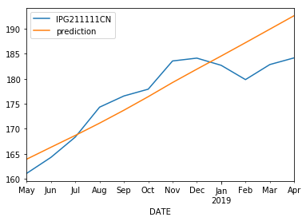

```python
test.plot()
```

```python
model.save('timeseries.h5')
```

```python
from keras.models import load_model
new_model = load_model('timeseries.h5')
```

Save the above LSTM model for future use and to forecast the crude oil in future time,

for future time forecasting we have to repeat the same procedure which we have apllied for test dataset prediction

before finalizing the model let's evaluate this dataset with well known time series forecasting methods called ARIMA and others from statsmodels

## StatsModels

Earlier we have analyze & predict time series analysis for Cruide oil with Prophet & Keras LSTM, now we will add more analysis technique called as ARIMA using StatsModels.

ARIMA - AutoRegressive Integration Moving avarage

This is widely used technique for time series analysis.

Let's get started:

Import required ststsmodels library with

1. adfuller => Use to find out that dataset is stationary or not
2. seasonal_decompose => Use to find out trend & seasonality in datset
3. auto_arima => use to find out value for p, q, r according to its method like ARMA,ARIMA
4. plot_acf, plot_pacf => gives value for autoregression that which is more important
5. rsme => use to find out root mean square error

```python
import pandas as pd
import statsmodels
from statsmodels.tsa.stattools import adfuller
from statsmodels.tsa.seasonal import seasonal_decompose
from pmdarima import auto_arima
from statsmodels.graphics.tsaplots import plot_acf,plot_pacf
from statsmodels.tsa.arima_model import ARMA,ARIMA,ARMAResults,ARIMAResults
import warnings
from statsmodels.tools.eval_measures import rmse
```

```python
warnings.filterwarnings('ignore')
```

```python
data1=pd.read_csv('IPG211111CN.csv',index_col='DATE',parse_dates=True).round(2)
data1.index.freq='MS'
data1.head()
```

| DATE | IPG211111CN |
| --- | --- |
| 1972-01-01 | 141.51 |
| 1972-02-01 | 145.17 |
| 1972-03-01 | 147.29 |
| 1972-04-01 | 148.22 |
| 1972-05-01 | 149.78 |

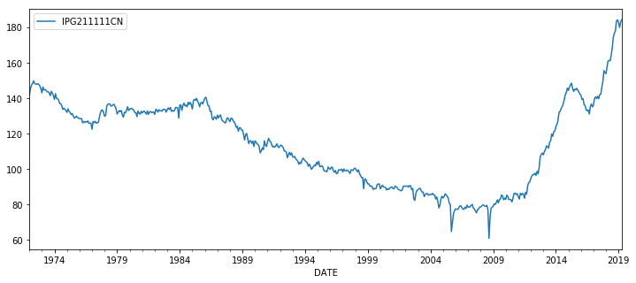

```python
%matplotlib inline
data1.plot(figsize=(12,5))
```

### adfuller Test

adfuller test is used to check that dataset is stationary or not

1. if p-value >0.05 then dataset is non-stationary
2. if p< 0.05 then datset is stationary
3. Here, we get p-value is 0.86 mean dataset is non stationary

```python
# adfuller test for stationarity or not
adfuller_result=adfuller(data1['IPG211111CN'])
adfuller_result
```

```
(-0.6180449008794604,
 0.8668522663132674,
 13,
 554,
 {'1%': -3.4422089502693454,
  '5%': -2.866771178805824,
  '10%': -2.5695560476482164},
 2334.416244804447)
```

### seasonal components checks

```
(<Figure size 432x288 with 4 Axes>,)
```

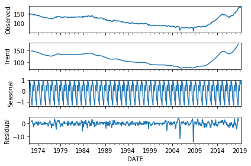

```python
%matplotlib inline
seasonality_checks=seasonal_decompose(data1['IPG211111CN'],model='additive')
seasonality_checks.plot(),
```

### Auto_arima test

1. auto_arima test gives us clear idea about which algorithms will best suite for the current dataset & its parameter value (p,q,r etc) with AIC & BIC acore

```python
auto_arima(data1['IPG211111CN'],seasonal=False).summary()
```

ARIMA Model Results

| Dep. Variable: | D2.y | No. Observations: | 566 |
| --- | --- | --- | --- |
| Model: | ARIMA(2, 2, 1) | Log Likelihood | -1203.211 |
| Method: | css-mle | S.D. of innovations | 2.022 |
| Date: | Wed, 29 May 2019 | AIC | 2416.421 |
| Time: | 07:39:15 | BIC | 2438.114 |
| Sample: | 2 | HQIC | 2424.888 |

|  | coef | std err | z | P>\|z\| | [0.025 | 0.975] |
| --- | --- | --- | --- | --- | --- | --- |
| const | 0.0024 | 0.002 | 1.275 | 0.203 | -0.001 | 0.006 |
| ar.L1.D2.y | -0.1340 | 0.043 | -3.108 | 0.002 | -0.218 | -0.049 |
| ar.L2.D2.y | -0.0879 | 0.043 | -2.040 | 0.042 | -0.172 | -0.003 |
| ma.L1.D2.y | -0.9750 | 0.011 | -86.824 | 0.000 | -0.997 | -0.953 |

Roots

|  | Real | Imaginary | Modulus | Frequency |
| --- | --- | --- | --- | --- |
| AR.1 | -0.7624 | -3.2863j | 3.3735 | -0.2863 |
| AR.2 | -0.7624 | +3.2863j | 3.3735 | 0.2863 |
| MA.1 | 1.0256 | +0.0000j | 1.0256 | 0.0000 |

```python
auto_arima(data1['IPG211111CN'],seasonal=False,stationary=True).summary()
```

ARMA Model Results

| Dep. Variable: | y | No. Observations: | 568 |
| --- | --- | --- | --- |
| Model: | ARMA(4, 0) | Log Likelihood | -1216.748 |
| Method: | css-mle | S.D. of innovations | 2.051 |
| Date: | Wed, 29 May 2019 | AIC | 2445.496 |
| Time: | 07:38:56 | BIC | 2471.548 |
| Sample: | 0 | HQIC | 2455.662 |

|  | coef | std err | z | P>\|z\| | [0.025 | 0.975] |
| --- | --- | --- | --- | --- | --- | --- |
| const | 146.7925 | 29.873 | 4.914 | 0.000 | 88.241 | 205.343 |
| ar.L1.y | 0.9254 | 0.042 | 22.129 | 0.000 | 0.843 | 1.007 |
| ar.L2.y | 0.0486 | 0.057 | 0.854 | 0.393 | -0.063 | 0.160 |
| ar.L3.y | 0.1044 | 0.057 | 1.827 | 0.068 | -0.008 | 0.216 |
| ar.L4.y | -0.0803 | 0.042 | -1.907 | 0.057 | -0.163 | 0.002 |

Roots

|  | Real | Imaginary | Modulus | Frequency |
| --- | --- | --- | --- | --- |
| AR.1 | 1.0017 | -0.0000j | 1.0017 | -0.0000 |
| AR.2 | -1.1287 | -1.8951j | 2.2057 | -0.3355 |
| AR.3 | -1.1287 | +1.8951j | 2.2057 | 0.3355 |
| AR.4 | 2.5564 | -0.0000j | 2.5564 | -0.0000 |

This is the overall summary of ARIMA selection

```python
stepwise_result=auto_arima(data1['IPG211111CN'],start_p=0,start_q=0,max_p=4,max_q=4,m=12,seasonal=False,d=None,trace=True,error_action='ignore'
                          ,suppress_warnings=True,stepwise=True)
stepwise_result.summary()
```

```
Fit ARIMA: order=(0, 2, 0); AIC=2862.724, BIC=2871.402, Fit time=0.004 seconds
Fit ARIMA: order=(1, 2, 0); AIC=2683.599, BIC=2696.615, Fit time=0.036 seconds
Fit ARIMA: order=(0, 2, 1); AIC=2424.390, BIC=2437.405, Fit time=0.150 seconds
Fit ARIMA: order=(1, 2, 1); AIC=nan, BIC=nan, Fit time=nan seconds
Fit ARIMA: order=(0, 2, 2); AIC=nan, BIC=nan, Fit time=nan seconds
Fit ARIMA: order=(1, 2, 2); AIC=nan, BIC=nan, Fit time=nan seconds
Total fit time: 0.299 seconds
```

ARIMA Model Results

| Dep. Variable: | D2.y | No. Observations: | 566 |
| --- | --- | --- | --- |
| Model: | ARIMA(0, 2, 1) | Log Likelihood | -1209.195 |
| Method: | css-mle | S.D. of innovations | 2.043 |
| Date: | Wed, 29 May 2019 | AIC | 2424.390 |
| Time: | 07:39:27 | BIC | 2437.405 |
| Sample: | 2 | HQIC | 2429.470 |

|  | coef | std err | z | P>\|z\| | [0.025 | 0.975] |
| --- | --- | --- | --- | --- | --- | --- |
| const | 0.0022 | 0.002 | 1.370 | 0.171 | -0.001 | 0.005 |
| ma.L1.D2.y | -0.9836 | 0.008 | -125.999 | 0.000 | -0.999 | -0.968 |

Roots

|  | Real | Imaginary | Modulus | Frequency |
| --- | --- | --- | --- | --- |
| MA.1 | 1.0167 | +0.0000j | 1.0167 | 0.0000 |

With plot_acf & plot_pacf . we can determind that which is more important here, Autoregression or Moving average Also we can confirm the p,q,r value also

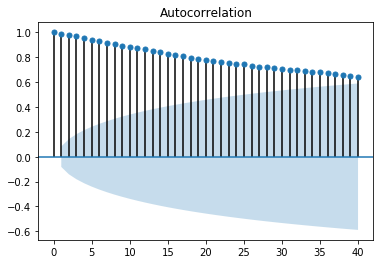

```python
plot_acf(data1['IPG211111CN'],title='Autocorrelation',lags=40);
```

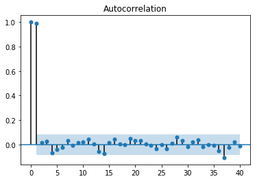

```python
plot_pacf(data1['IPG211111CN'],title='Autocorrelation',lags=40);
```

```python
len(data1)
```

```
568
```

Now , we require to split dataset for training & testing purpose

1. apply the ARIMA on given dataset with order=(2,2,1)

```python
train=data1.iloc[:556]
test=data1.iloc[556:]
```

```python
model=ARIMA(train['IPG211111CN'],order=(2,2,1))
resultd=model.fit()
resultd.summary()
```

ARIMA Model Results

| Dep. Variable: | D2.IPG211111CN | No. Observations: | 554 |
| --- | --- | --- | --- |
| Model: | ARIMA(2, 2, 1) | Log Likelihood | -1171.045 |
| Method: | css-mle | S.D. of innovations | 1.997 |
| Date: | Wed, 29 May 2019 | AIC | 2352.089 |
| Time: | 07:42:48 | BIC | 2373.675 |
| Sample: | 03-01-1972 | HQIC | 2360.522 |
|  | - 04-01-2018 |  |  |

|  | coef | std err | z | P>\|z\| | [0.025 | 0.975] |
| --- | --- | --- | --- | --- | --- | --- |
| const | 0.0019 | 0.002 | 1.153 | 0.250 | -0.001 | 0.005 |
| ar.L1.D2.IPG211111CN | -0.1524 | 0.043 | -3.514 | 0.000 | -0.237 | -0.067 |
| ar.L2.D2.IPG211111CN | -0.0931 | 0.043 | -2.145 | 0.032 | -0.178 | -0.008 |
| ma.L1.D2.IPG211111CN | -0.9784 | 0.010 | -93.928 | 0.000 | -0.999 | -0.958 |

Roots

|  | Real | Imaginary | Modulus | Frequency |
| --- | --- | --- | --- | --- |
| AR.1 | -0.8187 | -3.1743j | 3.2781 | -0.2902 |
| AR.2 | -0.8187 | +3.1743j | 3.2781 | 0.2902 |
| MA.1 | 1.0221 | +0.0000j | 1.0221 | 0.0000 |

1. With the trained model on trainig datset, now we will predict the future value and compare it with test datset
2. ARIMA took predict variable , with start & end form , so we will give start poing with lenght of train datset and end point with train + test -1 as index start with 0 and predict the future value

```python
start=len(train)
end=len(train)+len(test)-1
prediction = resultd.predict(start=start,end=end,dynamic=False,typ='levels')
prediction
```

```
2018-05-01    161.924374
2018-06-01    162.842348
2018-07-01    163.684086
2018-08-01    164.519881
2018-09-01    165.365994
2018-10-01    166.213404
2018-11-01    167.061974
2018-12-01    167.912564
2019-01-01    168.765055
2019-02-01    169.619386
2019-03-01    170.475576
2019-04-01    171.333630
Freq: MS, dtype: float64
```

1. belor rmse score gives us , how our model fit & gives accurate result
2. we got almost 11 as rmse score

```python
error=rmse(test['IPG211111CN'],prediction)
error
```

```
11.312468063752341
```

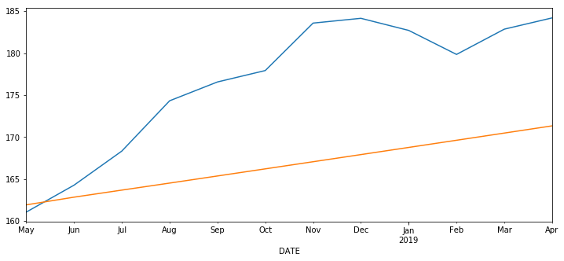

```python
test['IPG211111CN'].plot(figsize=(12,5),label='actual data')
prediction.plot(figsize=(12,5),label='actual data')
```

1. Now , let,s create model on whole datset and predict the future unseen date & its value

```python
model=ARIMA(data1['IPG211111CN'],order=(2,2,1))
resultd=model.fit()
```

[figure not shown]

```python
ax=data1['IPG211111CN'].plot(figsize=(12,5),label='actual data')
prediction1.plot()
```

So we have tried to predict future forecast cuide oil value with 3 technique